# Trabalho - Clima RJ

Hugo Batista

05/12/2022

Os dados foram filtrados para o estado do RJ para fazer a análise das variáveis

Carregando pacotes

```r
require(data.table)
require(arrow)
```

```r
require(corrplot)
require(tseries)
require(TTR)
```

Abrindo o banco de dados já filtrado e tratando as variáveis:

```r
dataset <- read_parquet("dados_rj.parquet")
dataset[, index := NULL]
names(dataset) <- c("date", "hr", "prcp", "stp", "smax", "smin", "gbrd",
                    "temp", "dewp", "tmax", "tmin", "dmax", "dmin", "hmax",
                    "hmin", "hmdy", "wdct", "gust", "wdsp", "region", "prov",
                    "wsnm", "inme", "lat", "lon", "elvt")
```

Analisando a correlação de Pearson entre as variáveis numéricas:

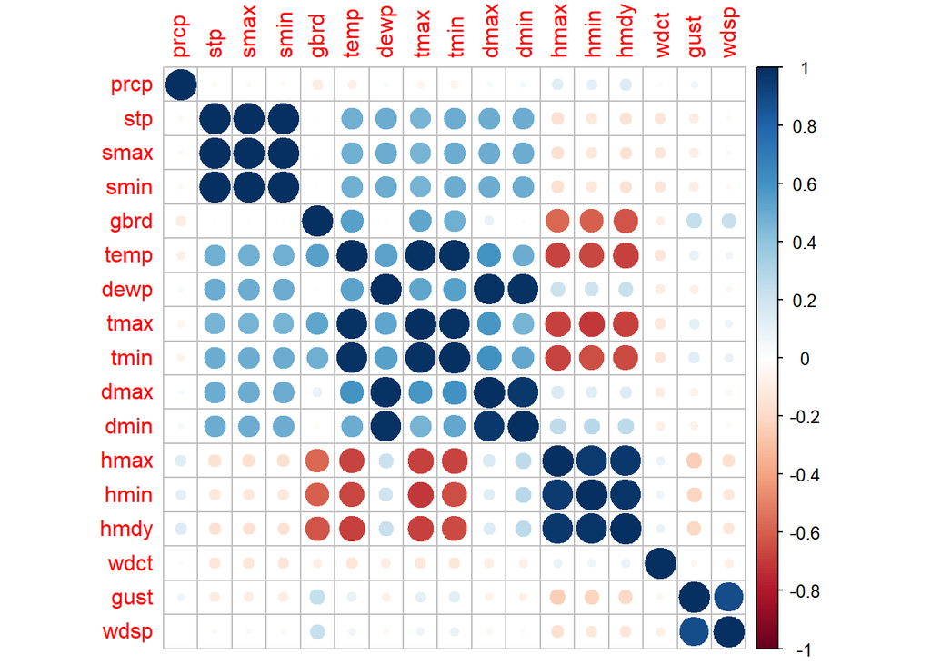

```r
dataset_cor <- dataset[, c("date","prcp", "stp", "smax", "smin", "gbrd",
                       "temp", "dewp", "tmax", "tmin", "dmax", "dmin", "hmax",
                       "hmin", "hmdy", "wdct", "gust", "wdsp")]
is.na(dataset_cor) <- dataset_cor == -9999.0
dataset_corg <- na.omit(dataset_cor)
corrplot(cor(dataset_corg[, date := NULL]), method = "circle")
```

```r
rm(dataset_corg)
```

Percebemos que as variáveis de pressão tem alta correlação entre si, assim como as variáveis de temperatura. Assim podemos selecionar apenas uma de cada tipo para análise.

Para as variáveis seguintes serão plotados os gráficos e teste de normalidade.

Temperatura máxima:

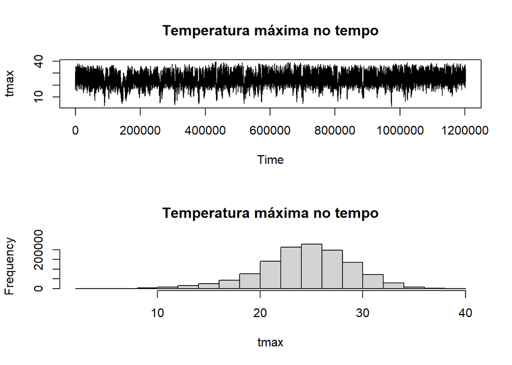

```r
dataset_cor1 <- na.omit(dataset_cor)

tmax <- TTR::runMean(dataset_cor1$tmax[], n=9)
par(mfrow=c(2,1))
plot.ts(tmax, main = "Temperatura máxima no tempo")
hist(tmax, main = "Temperatura máxima no tempo")
```

```r
jarque.bera.test(na.omit(tmax))
```

```
##
##  Jarque Bera Test
##
## data:  na.omit(tmax)
## X-squared = 56706, df = 2, p-value < 2.2e-16
```

```r
rm(tmax)
```

Vemos que a temperatura máxima não segue uma distribuição normal pelo teste Jarque Bera.

Precipitação total:

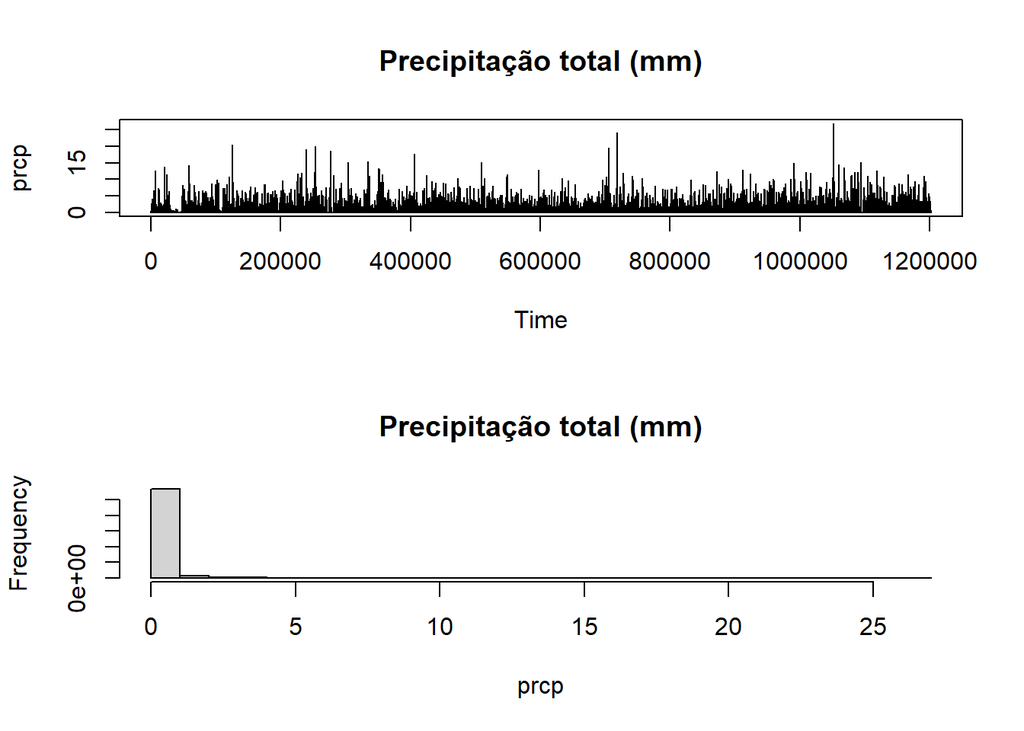

```r
dataset_cor1 <- na.omit(dataset_cor)

prcp <- TTR::runMean(dataset_cor1$prcp[], n=9)
par(mfrow=c(2,1))
plot.ts(prcp, main = "Precipitação total (mm)")
hist(prcp, main = "Precipitação total (mm)")
```

```r
jarque.bera.test(na.omit(prcp))
```

```
##
##  Jarque Bera Test
##
## data:  na.omit(prcp)
## X-squared = 645968811, df = 2, p-value < 2.2e-16
```

```r
rm(prcp)
```

Vemos que a precipitação total não segue uma distribuição normal pelo teste Jarque Bera além de percebermos vários pontos de outliers, porém a maioria dos valores estão entre 0 e 1.

Pressao atmosférica ao nivel da estação:

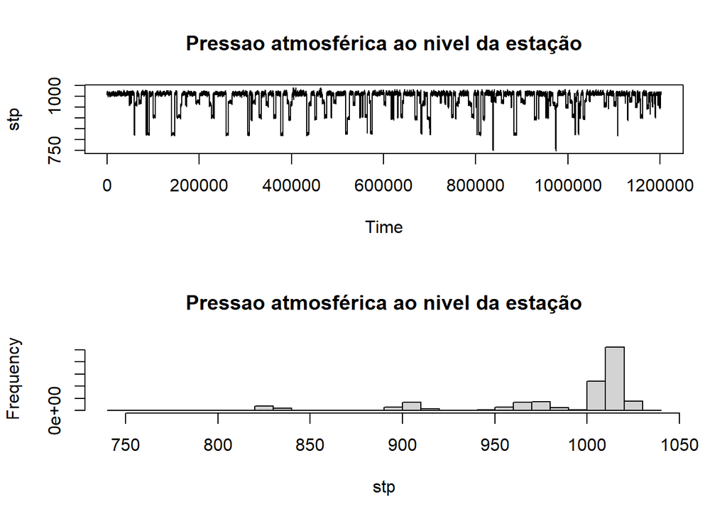

```r
dataset_cor1 <- na.omit(dataset_cor)

stp <- TTR::runMean(dataset_cor1$stp[], n=9)
par(mfrow=c(2,1))
plot.ts(stp, main = "Pressao atmosférica ao nivel da estação")
hist(stp, main = "Pressao atmosférica ao nivel da estação")
```

```r
jarque.bera.test(na.omit(stp))
```

```
##
##  Jarque Bera Test
##
## data:  na.omit(stp)
## X-squared = 1455560, df = 2, p-value < 2.2e-16
```

```r
rm(stp)
```

Pressão também não segue uma distribuição normal e percebemos um comportamento padrão nos níveis mais baixos pelo gráfico.

Vento rajada máxima:

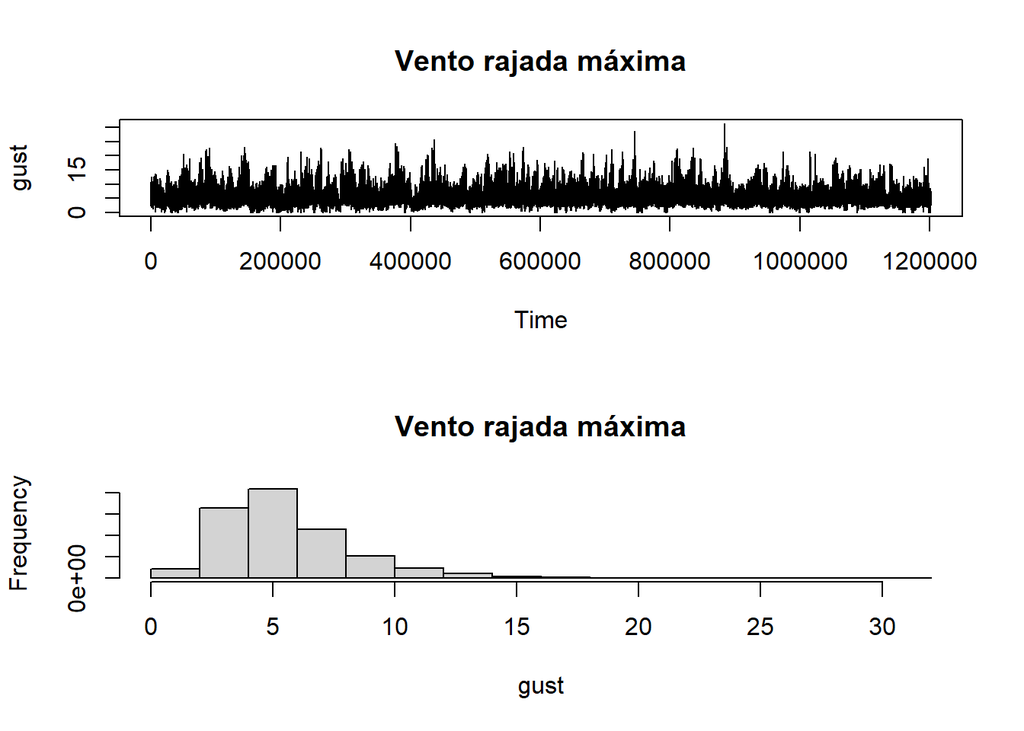

```r
dataset_cor1 <- na.omit(dataset_cor)

gust <- TTR::runMean(dataset_cor1$gust[], n=9)
par(mfrow=c(2,1))
plot.ts(gust, main = "Vento rajada máxima")
hist(gust, main = "Vento rajada máxima")
```

```r
jarque.bera.test(na.omit(gust))
```

```
##
##  Jarque Bera Test
##
## data:  na.omit(gust)
## X-squared = 556626, df = 2, p-value < 2.2e-16
```

```r
rm(gust)
```

Percebemos sazonalidade na rajada de vento máxima.

Fazendo um modelo com variável resposta temperatura máxima e com as covariáveis que foram destritidas acima:

```r
fit1 <- lm(formula = tmax ~ prcp + stp + gust, data = dataset_cor1)
summary(fit1)
```

```
##
## Call:
## lm(formula = tmax ~ prcp + stp + gust, data = dataset_cor1)
##
## Residuals:
##      Min       1Q   Median       3Q      Max
## -17.7955  -3.0645  -0.2561   2.9338  19.9432
##
## Coefficients:
##               Estimate Std. Error t value Pr(>|t|)
## (Intercept) -2.607e+01  8.207e-02 -317.66   <2e-16 ***
## prcp        -2.040e-01  3.031e-03  -67.32   <2e-16 ***
## stp          4.968e-02  8.205e-05  605.53   <2e-16 ***
## gust         2.693e-01  1.257e-03  214.27   <2e-16 ***
## ---
## Signif. codes:  0 '***' 0.001 '**' 0.01 '*' 0.05 '.' 0.1 ' ' 1
##
## Residual standard error: 4.432 on 1201922 degrees of freedom
## Multiple R-squared:  0.248,  Adjusted R-squared:  0.248
## F-statistic: 1.322e+05 on 3 and 1201922 DF,  p-value: < 2.2e-16
```

Percebemos que todas covariáveis deramsignificativas para temperatura máxima porém com intercepto muito baixo. Teríamos que avaliar outros meios de modelar pelo tempo.